# MATH9102-W4-ttest

Author

Deirdre Lawless

```r
quiet_library <- function(pkg) {
  suppressMessages(suppressWarnings({
    if (!requireNamespace(pkg, quietly = TRUE)) {
      install.packages(pkg, quiet = TRUE)
    }
    library(pkg, character.only = TRUE)
  }))
}
quiet_library("tidyverse")  # Collection of R packages (dplyr, ggplot2, tidyr, etc.) for data wrangling, visualization, and analysis
quiet_library("psych")   # Descriptive statistics by group
quiet_library("car")   # Includes Levene's test for homogeneity
quiet_library("effectsize")   # Includes calculations for effectsizequiet_library("pastecs")    # Tools for descriptive statistics, time series analysis, and data exploration (e.g., stat.desc)
quiet_library("FSA")        # Includes general tools for data analysis (e.g., nonparametric tests, bootstrapping)
quiet_library("semTools")   # Supplementary functions for Structural Equation Modeling (SEM), including model fit, reliability, and measurement invariance test


#Amend this to reflect your folder structure
datalocation <- file.path("C:","Users", "deirdre.lawless", "datafiles")
datapath <- file.path(datalocation,'survey.dat')

#Read in the dataset
survey <- read.table(datapath)

#Setting the column names to be that used in the dataset but in lowercase to make life a bit easier
colnames(survey) <- tolower(colnames(survey))
```

# Investigate Difference in Perceived Stress Levels for Those With or Without Children

This analysis investigate the following hypothesis:

H0: There is no difference in perceived stress scores for respondents who have children and respondents who do not have children HA: There is a difference in perceived stress scores for respondents who have children and respondents who do not have children

The sample consisted of respondents who either had children or did not. Out of the total sample, 42.24% reported having children, while 57.76% did not have children, see Table 1 and Figure 1.

```r
# Create a frequency table for the numbers in each group
child_freq <- table(survey$child)

# Percentage table
child_perc <- prop.table(child_freq) * 100

# Combine frequencies and percentages
child_summary <- cbind(Frequency = child_freq, Percentage = round(child_perc, 2))
```

```r
# Print the combined table with frequencies and percentages
print(child_summary)
```

```
    Frequency Percentage
NO        253      57.76
YES       185      42.24
```

```r
# Filter out NA values from the 'child' variable only
cleaned_survey <- survey %>%
  filter(!is.na(child))
```

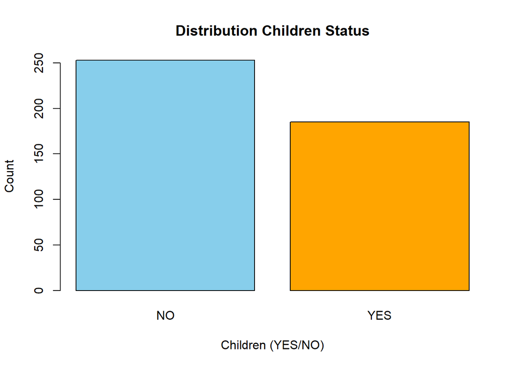

Figure 1: Bar Chart Showing Number of Respondents By Children Status

```r
# Base R bar chart
barplot(table(survey$child),
        main = "Distribution Children Status",
        xlab = "Children (YES/NO)",
        ylab = "Count",
        col = c("skyblue", "orange"))
```

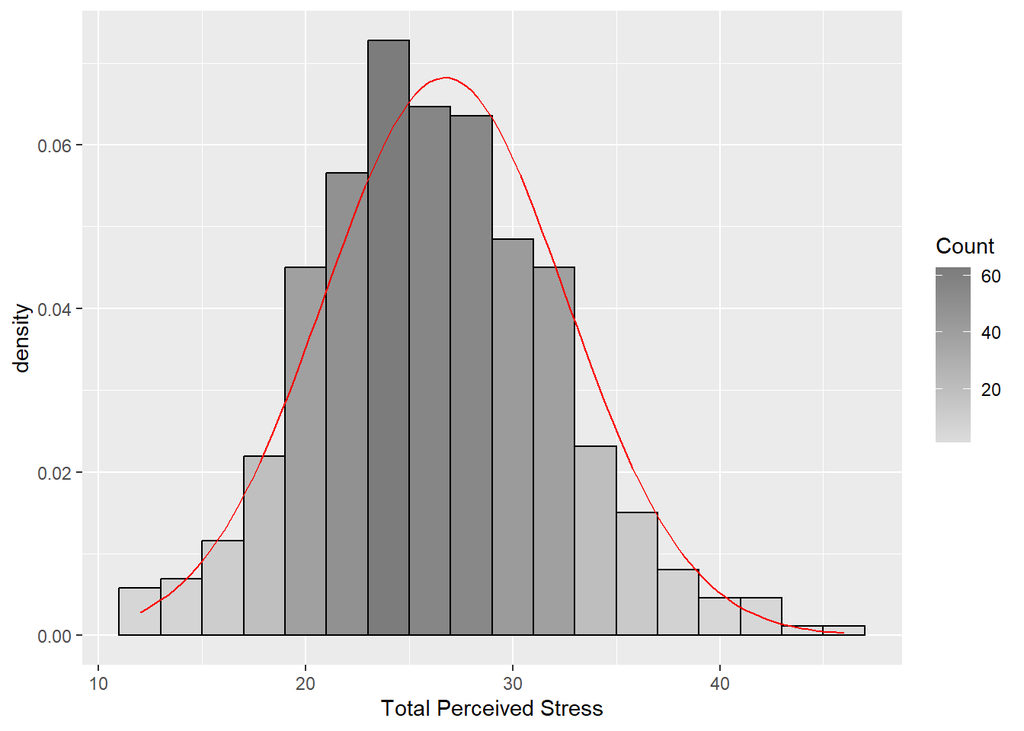

Figure 2: Histogram of Total Perceived Stress

```r
#Create histogram
gs <- ggplot(survey, aes(x=tpstress))
gs <- gs + labs(x="Total Perceived Stress")
gs <- gs + geom_histogram(binwidth=2, colour="black", aes(y=..density.., fill=..count..))
gs <- gs + scale_fill_gradient("Count", low="#DCDCDC", high="#7C7C7C")
gs <- gs + stat_function(fun=dnorm, color="red",args=list(mean=mean(survey$tpstress, na.rm=TRUE), sd=sd(survey$tpstress, na.rm=TRUE)))
gs
```

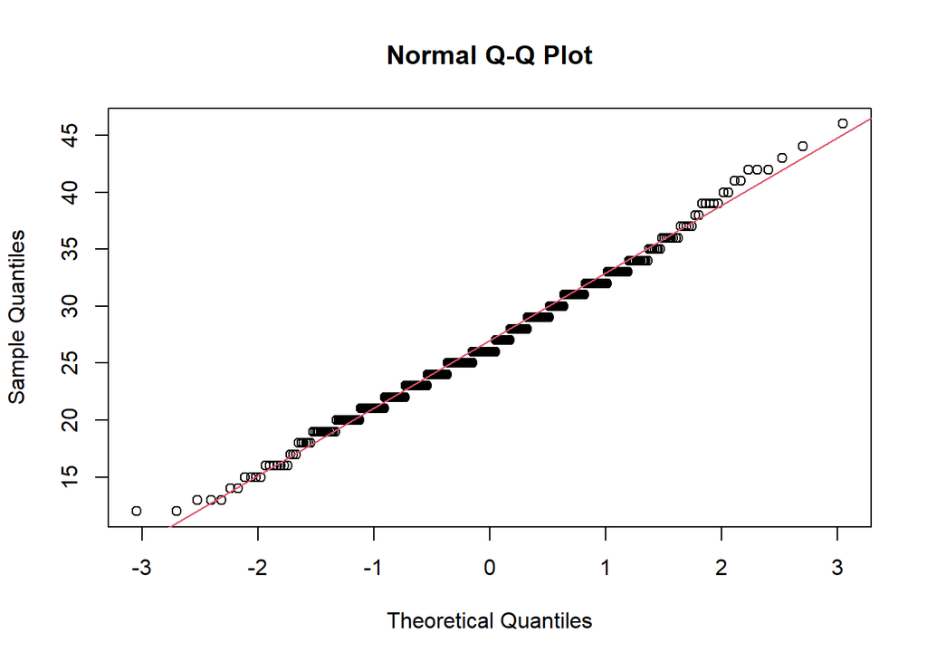

Figure 3: QQPlot for Total Perceived Strees

```r
#Create a qqplot
qqnorm(survey$tpstress)
qqline(survey$tpstress, col=2) #show a line on theplot
```

```r
#Generate regular summary statistics
pastecs::stat.desc(survey$tpstress, basic=F)
```

```
      median         mean      SE.mean CI.mean.0.95          var      std.dev
  26.0000000   26.7274827    0.2810163    0.5523293   34.1940809    5.8475705
    coef.var
   0.2187849
```

```r
#Generate standardized scores for skewness and kurtosis
tpskew<-semTools::skew(survey$tpstress)
tpkurt<-semTools::kurtosis(survey$tpstress)
tpskew[1]/tpskew[2]
```

```
skew (g1)
 2.084689
```

```r
tpkurt[1]/tpkurt[2]
```

```
Excess Kur (g2)
      0.7711362
```

```r
#Calculate the percentage of standardized scores outside acceptable limits
ztpstress<- abs(scale(survey$tpstress))

FSA::perc(as.numeric(ztpstress), 1.96, "gt")
```

```
[1] 6.004619
```

```r
FSA::perc(as.numeric(ztpstress), 3.29, "gt")
```

```
[1] 0.2309469
```

```r
# Below we are reporting the normality assessment - embedding code within a paragraph to get the statistics generated ( you can just write it out)
```

Total Perceived Stress scrires were assessed for normality. Visual inspection of the histogram and QQ-Plot (see Figure 2 and Figure 3) identified some issues with skewness and kurtosis. While the standardized score for kurtosis (0.77) could be considered acceptable using the criteria proposed by Curran, West and Finch (1996), but the standardized score for skewness (2.08) was outside the acceptable range. However as over 99% of standardized scores fall within the bounds of +/- 3.29, using the guidance of Field, Miles and Field (2012), the data can be considered to approximate a normal distribution (m=26.73, sd=5.85, n=433).

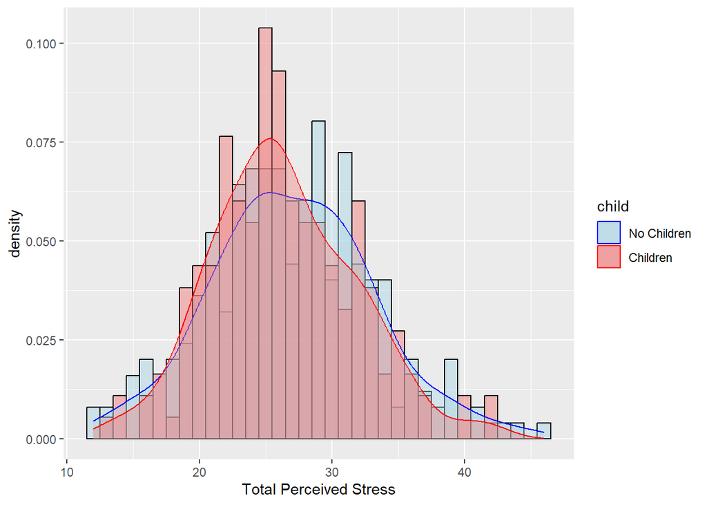

Figure 5: Histogram of Total Perceivced Stress Grouped by Repondent’s Children Status

```r
# Create a separate histogram showing the distribution for the two (potentially) separate populations (the groups)
# Create the plot with both histogram and density plot
ggplot(cleaned_survey, aes(x=tpstress, color=child, fill=child))  +
  labs(x="Total Perceived Stress") +
  # Histogram with alpha for transparency
  geom_histogram(aes(y = ..density..), position="identity", alpha=0.5, binwidth=1, color="black") +
  # Density plot with transparency for overlapping curves
  geom_density(alpha=0.4) +
  # Customize the color and fill scales
  scale_color_manual(values=c("blue", "red"), labels=c("No Children", "Children")) +
  scale_fill_manual(values=c("lightblue", "lightcoral"), labels=c("No Children", "Children"))
```

```r
#Get descriptive stastitics by group - output as a matrix
psych::describeBy(survey$tpstress, survey$child, mat=TRUE)
```

```
    item group1 vars   n     mean       sd median  trimmed    mad min max range
X11    1     NO    1 249 27.03614 6.133815     27 26.94030 5.9304  12  46    34
X12    2    YES    1 183 26.33880 5.425314     26 26.18367 5.9304  13  42    29
         skew   kurtosis        se
X11 0.1774908 0.11991223 0.3887147
X12 0.2976439 0.06086413 0.4010508
```